# Batch-28 CSE7112c Full Lab Day

26 March 2017

Review of previous day exercise:

## Vectors

### Create a vector with numeric values from 1 to 10

1. The function ‘sequence’ is used to generate a sequence of numbers

```r
seq(1,10,1)
```

```
##  [1]  1  2  3  4  5  6  7  8  9 10
```

```r
seq_len(10)
```

```
##  [1]  1  2  3  4  5  6  7  8  9 10
```

```r
c(1:10)
```

```
##  [1]  1  2  3  4  5  6  7  8  9 10
```

2. Add two vectors of same length & different lengths

```r
a = c(1,2,3,4)
b = c(7,8,9,10)

c = c(1,2,3,4)
d = c(7,8)

print(a+b)
```

```
## [1]  8 10 12 14
```

```r
print(c+d)
```

```
## [1]  8 10 10 12
```

### Create a vector of random numbers

1. ‘sample’ function

```r
sample(c(1:10),1)
```

```
## [1] 4
```

2. Create a vector with some probabilities

```r
sample(c(1:5),size=1,prob=c(0.5,0.2,0.1,0.1,0.1))
```

```
## [1] 1
```

3. Lets create a vector and find its mean

```r
v<-c(1,4,5,6,8)
mean(v)
```

```
## [1] 4.8
```

```r
sd(v)
```

```
## [1] 2.588436
```

4. It is not very uncommon to have a data with missing values. For eg:

```r
v<-c(1,4,5,NA,8)
is.na(v)
```

```
## [1] FALSE FALSE FALSE  TRUE FALSE
```

5. On this data we would like to compute the mean. Observe the syntax of mean function and write the code

```r
mean(v,na.rm=T)
```

```
## [1] 4.5
```

### Precedence in vector

```r
A = c(1,"a",TRUE)
str(A)
```

```
##  chr [1:3] "1" "a" "TRUE"
```

### Subsetting

Create a vector.

```r
V<-c(1:10)
```

Extract the 5th element

```r
V[5]
```

```
## [1] 5
```

Extract the elements from index 5 to 7

```r
V[5:7]
```

```
## [1] 5 6 7
```

Extract the 2nd, 5th and 9th element

```r
V[c(2,5,9)]
```

```
## [1] 2 5 9
```

Remove 4th element from the list

```r
V = V[-4]
```

Replace 7th element with 100

```r
V[7]<-100
```

Find the number of elements in a vector

```r
length(V)
```

```
## [1] 9
```

```r
V[max(V)]
```

```
## [1] NA
```

We would like to replace the missing value with some other value

```r
v<-c(1,3,4,NA,7)
v[is.na(v)]=999
```

## Matrix-2D (Arrays for multidimentional matrices)

```r
A = matrix(c(1:6), nrow=T,ncol = 2)
```

### Subsetting

Extract 2 nd row second element of the matrix

```r
A = matrix(c(1:6),ncol = 2, byrow = T)
print(A[2,2])
```

```
## [1] 4
```

Extract entire first row

```r
A[1,]
```

```
## [1] 1 2
```

### Naming columns of a matrix

Assign colnames as

```r
colnames(A) = c("x1", "x2")
```

```r
B = matrix(c(1:4),nrow=2,dimnames=list(c("Actual0","Actual1"),c("Predicted0","Predicted1")))
```

Can a matrix have data of different datatypes

```r
mat=matrix(c(1,"2",TRUE,0),nrow=2,byrow = T)
mat
```

```
##      [,1]   [,2]
## [1,] "1"    "2"
## [2,] "TRUE" "0"
```

## Dataframes

Create a dataframe with 0 values 3 columns and 5 observations

```r
data<-data.frame(matrix(0,nrow=5,ncol=3, dimnames=list(c(),c("Age","Income","Experience"))))
str(data)
```

```
## 'data.frame':    5 obs. of  3 variables:
##  $ Age       : num  0 0 0 0 0
##  $ Income    : num  0 0 0 0 0
##  $ Experience: num  0 0 0 0 0
```

Create a dataframe with 5 observations and three variables- Let this be the data of 5 employees of an organization

```r
data1<-data.frame(Age=c(25,28,23,31,29),Gender=c("F","M","F","F","M"),Income=c(7,4.5,3.9,10.5,10))
```

For the same employees, we have education details in another dataframe

```r
data2<-data.frame(Age=c(25,28,23,31,29),Edu=c("B.Tech","B.E","B.Sc","PhD","M.Tech"))
```

Now we would like to have this data of employees in one frame

Task2: Let us say we have data (employee records) in two different dataframes and we would want all these records in one dataframe- rbind stand for row bind. Syntax for rbind is rbind(<dataframe1,dataframe2). Observe the output

```r
data1_rb<-data.frame(Name=c("Alice","Bob","Charlie"),Age=c(23,24,26),Edu=c("BS","MSc","MTech"))
data2_rb<-data.frame(Name=c("Brian","Danny","Amy"),Age=c(32,21,28),Edu=c("PhD","BS","MPhil"))
data3_rb<-rbind(data1_rb,data2_rb)
```

# Merge

```r
data3<-merge(data1,data2)
```

Explore Merge command-

```r
test1<-data.frame(Name=c("Alice","Bob","Charlie"),Age=c(25,26,27))
test2<-data.frame(Name=c("Alice","Brian","Danny","Charlie"),Edu=c("BS","PhD","MS","MS"))
```

Task1: To obtain age and education info of all employees in test1

```r
test3<-merge(test1, test2, by = "Name", all.x = TRUE)
```

Task2: To obtain age and education info of all employees in test2

```r
test3<-merge(test1, test2, by = "Name", all.y = TRUE)
```

Task3: To obtain age and education info of all employees in both test1 and test2

```r
test3<-merge(test1, test2, by = "Name", all = TRUE)
```

# Subsetting dataframes

consider the “rbinded” dataframe from task5. Let us perform some subetting operations

To obtain third record from this data

```r
data3_rb[3,] #number before comma is row and after comma is column. If nothing specified befor e or after comma then consider all rows and all columns
```

```
##      Name Age   Edu
## 3 Charlie  26 MTech
```

To extract only name column from the data and create a dataframe

```r
x<-data.frame(Name=data3_rb[,1])
```

To extract all the employees whose educational qualification is BS

```r
x_BS<-data3_rb[data3_rb$Edu=="BS",]
```

Task6. Extract all the employees whose age is greater than 26, their names and edu

```r
X_Age<-data3_rb[data3_rb$Age>26,c("Name","Edu")]
```

Task7. While working with vectors you have extracted the maximum value out of it.Now in this data, extract the record of oldest (in age) employee

```r
data3_rb[which.max(data3_rb$Age),]
```

```
##    Name Age Edu
## 4 Brian  32 PhD
```

# Conditionals using ifelse

Assume that, in an employee dataset you may have so many degree names. You want to group them into two buckets like “Doctoral” or “Non-Doctoral” ifelse

```r
data3_rb$Degree<-ifelse(data3_rb$Edu=="PhD","Doctoral","Non-Doctoral")
```

If we want to bucket them into more than two buckets- use nested if-else

```r
data3_rb$Degree<-ifelse(data3_rb$Edu=="PhD","Doctoral",ifelse(data3_rb$Edu=="BS","Bachelors","Masters"))
```

Lets start working with some in-built datasets

```r
attach(iris)
data<-iris
```

Summary statistics of the data

```r
str(data)
```

```
## 'data.frame':    150 obs. of  5 variables:
##  $ Sepal.Length: num  5.1 4.9 4.7 4.6 5 5.4 4.6 5 4.4 4.9 ...
##  $ Sepal.Width : num  3.5 3 3.2 3.1 3.6 3.9 3.4 3.4 2.9 3.1 ...
##  $ Petal.Length: num  1.4 1.4 1.3 1.5 1.4 1.7 1.4 1.5 1.4 1.5 ...
##  $ Petal.Width : num  0.2 0.2 0.2 0.2 0.2 0.4 0.3 0.2 0.2 0.1 ...
##  $ Species     : Factor w/ 3 levels "setosa","versicolor",..: 1 1 1 1 1 1 1 1 1 1 ...
```

```r
summary(data)
```

```
##   Sepal.Length    Sepal.Width     Petal.Length    Petal.Width
##  Min.   :4.300   Min.   :2.000   Min.   :1.000   Min.   :0.100
##  1st Qu.:5.100   1st Qu.:2.800   1st Qu.:1.600   1st Qu.:0.300
##  Median :5.800   Median :3.000   Median :4.350   Median :1.300
##  Mean   :5.843   Mean   :3.057   Mean   :3.758   Mean   :1.199
##  3rd Qu.:6.400   3rd Qu.:3.300   3rd Qu.:5.100   3rd Qu.:1.800
##  Max.   :7.900   Max.   :4.400   Max.   :6.900   Max.   :2.500
##        Species
##  setosa    :50
##  versicolor:50
##  virginica :50
##
##
##
```

# Loops

If we want to find the mean of each of the variables in the data

```r
avg<-c()
for(i in 1:4){
  avg[i]<-mean(data[,i])

}
```

# Smarter way of doing-Apply functions

```r
avg1<-apply(data[,-5],2,FUN=mean)
```

Lets say we want mean and standard deviation for each of the variable

```r
f<-function(x){
a<-c(mean(x),sd(x))
return(a)
}
avg2<-apply(data[,-5],2,FUN=f)
```

There are other variants of apply which we shall discuss during the next classes

# Visualizations

For this iris dataset- what is the petal width distribution across species

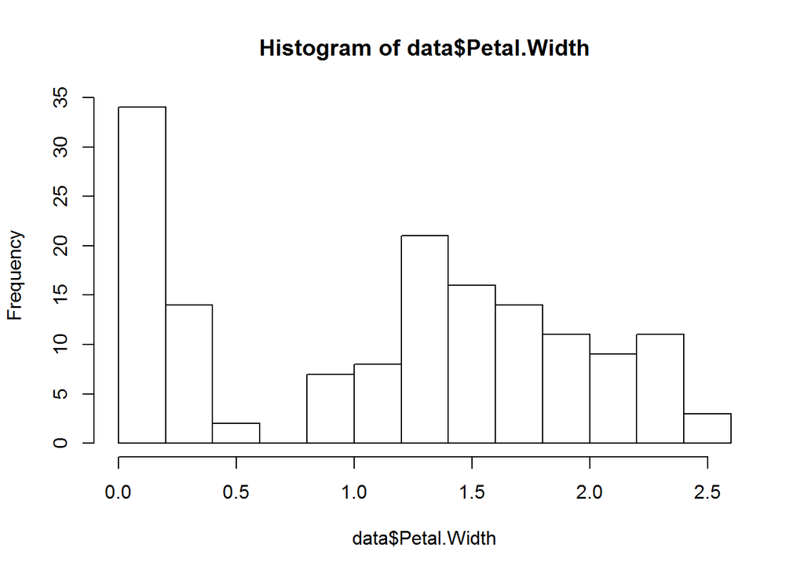

```r
hist(data$Petal.Width)
```

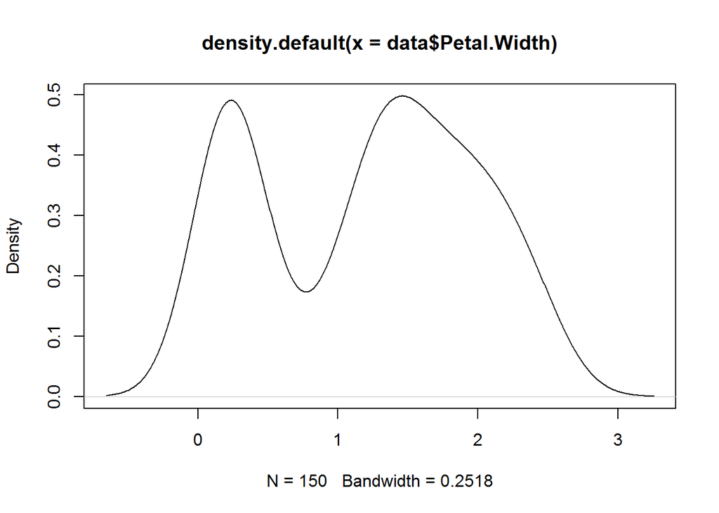

```r
plot(density(data$Petal.Width))
```

Obtain the petal width distribution only for setosa

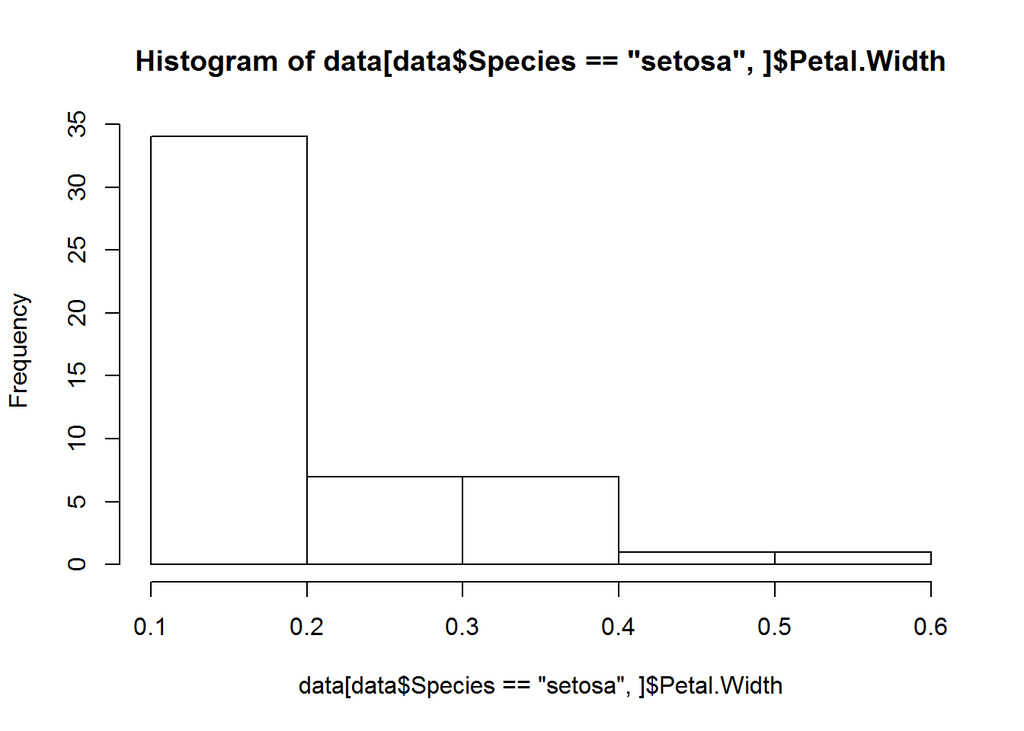

```r
hist(data[data$Species=="setosa",]$Petal.Width)
```

We have learnt that boxplots are appropriate to look for any extreme values or any anamolies in the distribution of data. What are your observations

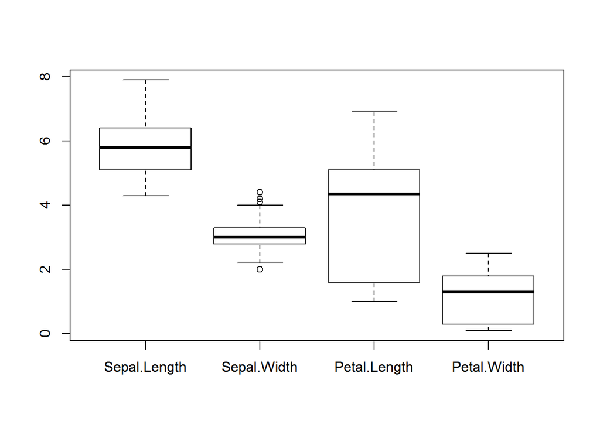

```r
boxplot(data[,-5])
```

Is there as relationship between the petal length and petal width across species

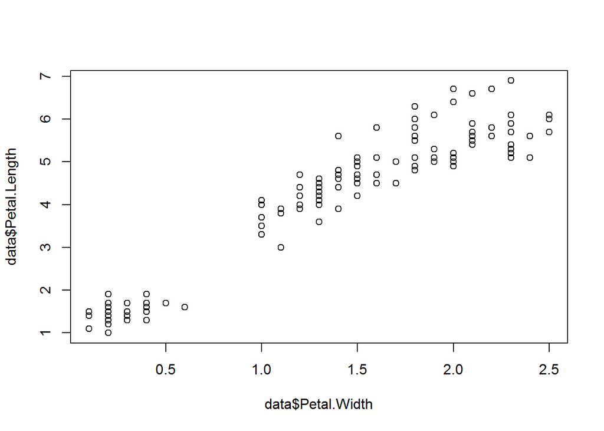

```r
plot(data$Petal.Width,data$Petal.Length)
```

## Reading data into R

Till now we have worked on built-in datasets. Now lets learn how to read data into R

```r
setwd("C:\\Users\\Pavan\\Downloads\\20170211_Batch 26_CSE7315c_RPreprocessingLab\\20170211_Batch 26_CSE7315c_RPreprocessingLab\\Data ")
data_read<-read.csv("Grade1.csv",header=T,sep=",")
```

Task1. obtain the mean values of each subject for the students Task2. Create a new variable called “class”, if percentage is <40 “fail”, if less than 60 “second”, if less than 70 “first” and greater than 70 then “distinction.

```r
str(data_read)
```

```
## 'data.frame':    20 obs. of  6 variables:
##  $ Student.id : int  1 2 3 4 5 6 7 8 9 10 ...
##  $ English1   : int  67 52 66 30 56 75 80 68 48 62 ...
##  $ Math1      : int  78 72 56 42 53 53 47 75 36 34 ...
##  $ Science1   : int  30 67 55 44 48 77 37 30 68 54 ...
##  $ OverallPct1: int  58 64 59 39 52 68 55 58 51 50 ...
##  $ grade      : int  2 1 2 3 2 1 2 2 2 2 ...
```

When you read data into R, it interprets the data type of the variable. Sometimes it is right and sometimes it might not be appropriate.Now in Grade1.csv,we have a variable “grade”. This is actually a “factor” but it is interpreted as “int”.

```r
data_read$grade<-as.numeric(as.character(data_read$grade))
```

```r
data_read$grade<-as.factor(as.character(data_read$grade))
```

Writing a data to csv file

```r
write.csv(data_read,file="data.csv",row.names=F)
```